# deep learning for euro dollar prediction

kuldeep singh bhati

The aim of the project is to train deep neural network using DN SAE model and predict next bar up and down for euro/dollar. Input data for the project use https://github.com/kuldeepldec/deep-machine-learning-on-euro-dollar1

## Libraries required for the project

```r
library(caret)
library(deepnet)
library(quantmod)
library(rminer)
library(TTR)
```

```r
set.seed(1)
```

### first read table euro/dollar 26 minute data data.

```r
price<-read.table("euro.txt",header=TRUE,sep=",")
price=subset(price[,3:6])
```

```r
Med <- (price[,2] + price[,3])/2
CO <- price[, 4] - price[, 1]
```

### Add Med and CO prices to the matrix

```r
price <- cbind(price, Med, CO)
```

## Now producing indicators for input data,making an Input function

```r
Input<-function(p = 14){
  adx<-ADX(price, n = p)
  ar<-aroon(price[ ,c('High', 'Low')], n=p)[ ,'oscillator']
  cci<-CCI(price[ ,2:4], n = p)
  chv<-chaikinVolatility(price[ ,2:4], n = p)
  cmo<-CMO(price[ ,'Med'], n = p)
  macd<-MACD(price[ ,'Med'], 12, 26, 9)[ ,'macd']
  osma<-macd - MACD(price[ ,'Med'],12, 26, 9)[ ,'signal']
  rsi<-RSI(price[ ,'Med'], n = p)
  stoh<-stoch(price[ ,2:4],14, 3, 3)
  vol<-volatility(price[ ,1:4],n = p,calc="yang.zhang", N=96)
  xavg<-EMA(price[,4],n=p)
  trend<-price[,4]-xavg;
  atr5<-ATR(HLC(price),5)
  atr5<-atr5[,2]

  Input<-cbind(adx, ar, cci, chv, cmo, macd, osma, rsi, stoh,vol,xavg,trend,atr5)
  return(Input)
}
```

### to access In Function

```r
X<-Input()
```

```r
Out<-function(ch=0.0037){

  zz<-ZigZag(price[ ,'Med'], change = ch, percent = F, retrace = F, lastExtreme = T)
  n<-1:length(zz)
  # On the last bars substitute the undefined values for the last known ones
  for(i in n) { if(is.na(zz[i])) zz[i] = zz[i-1]}
  #Define the speed of ZigZag changes and move one bar forward
  dz<-c(diff(zz), NA)
  #If the speed >0 - signal = 0(Buy), if <0, signal = 1 (Sell) otherwise NA
  sig<-ifelse(dz>0, 0, ifelse(dz<0, 1, NA))
  return(sig)
}
```

```r
Y<-Out()
table(Y)
```

```
## Y
##     0     1
## 24124 23684
```

## clearing Na values using clearing function

```r
Clearing<-function(x, y){
  dt<-cbind(x,y);
  n<-ncol(dt)
  dt<-na.omit(dt)
  return(dt);
}
```

```r
dt<-Clearing(X,Y)
```

## Balancing function check if 1 and 0 signal are equal or not, if they are not equal it insert 0 to columns of y with 1.

```r
Balancing<-function(DT){
  #Calculate a table with a number of classes
  cl<-table(DT[ ,ncol(DT)]);
  #If the divergence is less than 15%, return the initial matrix
  if(max(cl)/min(cl)<= 1.15) return(DT)
  #Otherwise level by the greater side
  DT<-if(max(cl)/min(cl)> 1.15){
         upSample(x = DT[ ,-ncol(DT)],y = as.factor(DT[ , ncol(DT)]), yname = "Y")
        }
  #Convert ? (factor) into a number
  DT$Y<-as.numeric(DT$Y)
  #Recode ? from 1,2 into 0,1
  DT$Y<-ifelse(DT$Y == 1, 0, 1)
  #Convert dataframe to matrix
  DT<-as.matrix(DT)
  return(DT);
}
```

### Seperating value of x and Y

```r
dt.b<-Balancing(dt)
x<-dt.b[ ,-ncol(dt.b)]
y<-dt.b[ , ncol(dt.b)]
```

## dividing our data into train and test data set

```r
t<-holdout(y, ratio = 8/10, mode = "random")
```

The t object is a list containing indices of the training (t$tr) and the test (t$ts) data set. The received sets are stratified.

#### preProcessing data as Neural networks can receive the input variables in the range (-1; 1) or (0, 1). Normalize the input variables into the range of [-1, 1].

```r
spSign<-preProcess(x[t$tr, ], method = "spatialSign")
x.tr<-predict(spSign, x[t$tr, ])
x.ts<-predict(spSign, x[t$ts, ])
```

## We are going to build and train the DN SAE model.

```r
SAE<-sae.dnn.train(x= x.tr, y= y[t$tr], hidden=c(50,50,50), activationfun = "tanh", learningrate = 0.6, momentum = 0.5, learningrate_scale = 1.0, output = "sigm", sae_output = "linear", numepochs = 10, batchsize = 100, hidden_dropout = 0, visible_dropout = 0)
```

```
## begin to train sae ......
```

```
## training layer 1 autoencoder ...
```

```
## training layer 2 autoencoder ...
```

```
## training layer 3 autoencoder ...
```

```
## sae has been trained.
```

```
## begin to train deep nn ......
```

```
## deep nn has been trained.
```

As we can see, it happens in two stages. At first autoencoder gets trained layer by layer and then the neural network.

## Let us evaluate forecasts on the test set of predictors.

```r
pr.sae<-nn.predict(SAE, x.ts)
```

### Convert into the levels 0,1 and calculate measurements

```r
pr<-ifelse(pr.sae>mean(pr.sae), 1, 0)
confusionMatrix(y[t$ts], pr)
```

```
## Confusion Matrix and Statistics
##
##           Reference
## Prediction    0    1
##          0 3585 1263
##          1 1403 3304
##
##                Accuracy : 0.721
##                  95% CI : (0.7119, 0.73)
##     No Information Rate : 0.522
##     P-Value [Acc > NIR] : < 2.2e-16
##
##                   Kappa : 0.4416
##  Mcnemar's Test P-Value : 0.007101
##
##             Sensitivity : 0.7187
##             Specificity : 0.7235
##          Pos Pred Value : 0.7395
##          Neg Pred Value : 0.7019
##              Prevalence : 0.5220
##          Detection Rate : 0.3752
##    Detection Prevalence : 0.5074
##       Balanced Accuracy : 0.7211
##
##        'Positive' Class : 0
##
```

## Predicting profit on last 1000 bars

```r
new.x<-predict(spSign,tail(dt[ ,-ncol(dt)], 1000))
pr.sae1<-nn.predict(SAE, new.x)

pr.sig<-ifelse(pr.sae1>mean(pr.sae1), -1, 1)
table(pr.sig)
```

```
## pr.sig
##  -1   1
## 492 508
```

```r
new.y<-ifelse(tail(dt[, ncol(dt)], 1000) == 0, 1, -1)
table(new.y)
```

```
## new.y
##  -1   1
## 483 517
```

```r
cm1<-confusionMatrix(new.y, pr.sig)
cm1
```

```
## Confusion Matrix and Statistics
##
##           Reference
## Prediction  -1   1
##         -1 360 123
##         1  132 385
##
##                Accuracy : 0.745
##                  95% CI : (0.7168, 0.7718)
##     No Information Rate : 0.508
##     P-Value [Acc > NIR] : <2e-16
##
##                   Kappa : 0.4897
##  Mcnemar's Test P-Value : 0.6164
##
##             Sensitivity : 0.7317
##             Specificity : 0.7579
##          Pos Pred Value : 0.7453
##          Neg Pred Value : 0.7447
##              Prevalence : 0.4920
##          Detection Rate : 0.3600
##    Detection Prevalence : 0.4830
##       Balanced Accuracy : 0.7448
##
##        'Positive' Class : -1
##
```

## Test the profit for the last 1000 bars using our predicted signals and get the balance curve:

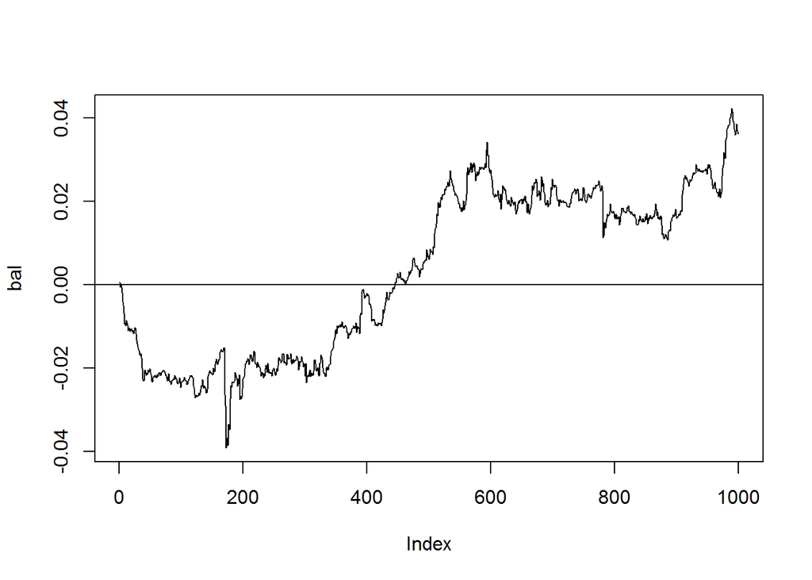

```r
bal<-cumsum(tail(price[ , 'CO'], 1000) * pr.sig)
plot(bal, t = "l")
abline(h = 0)
```

##Now compare with the balance that would have been obtained from the ideal signals of ZZ. The red line is the balance by the neural network signals:

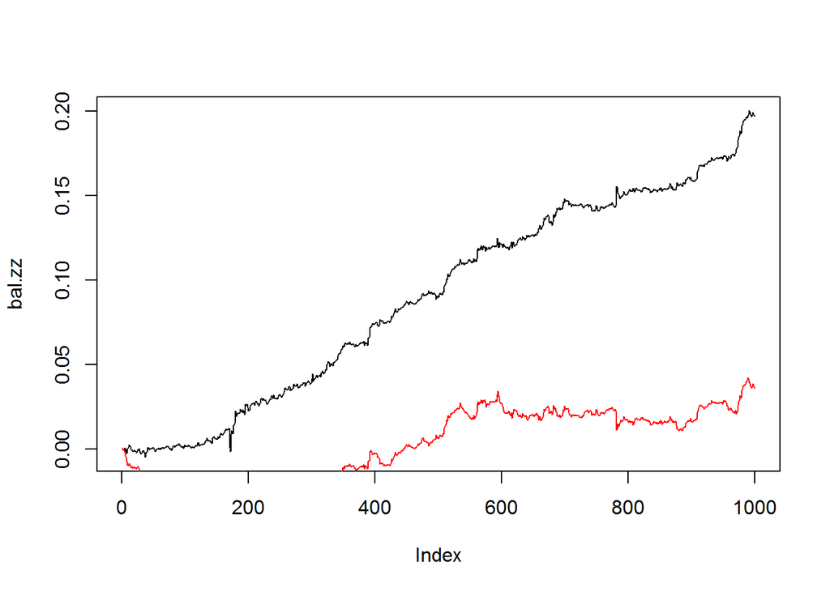

```r
bal.zz<-cumsum(tail(price[ , 'CO'], 1000) * new.y)
plot(bal.zz,  t = "l")
lines(bal,  col = 2)
```